# Explorando el Caso Banco Portugues - Bank Marketing

Nestor Montano | SEE

22 de mayo de 2020

# Caso Banco Portugues - Bank Marketing

Se ha producido una disminución de ingresos para el Banco Portugués y les gustaría saber qué medidas tomar. Después de la investigación se descubre que la causa principal es que sus clientes no están depositando con tanta frecuencia como antes. Además, se conoce que:

Los depósitos a plazo permiten a los bancos retener un depósito por un período de tiempo específico, de tal manera que el banco invierta en productos financieros de mayor ganancia y que además,  
Hay más posibilidad de persuadir a un clientes con depósito a plazo para que compre otro productos como fondos o seguros y así aumentar aún más el ingreso del banco. El Banco Portugués decide entonces hacer una campaña para promover depósitos a plazo, para ello su departamento de inteligencia debe **identificar a los clientes existentes que tienen mayores posibilidades de suscribirse a un depósito a plazo** y de esta manera enfocar el esfuerzo de marketing en dichos clientes

Fuente: [Moro et al., 2014] S. Moro, P. Cortez and P. Rita. A Data-Driven Approach to Predict the Success of Bank Telemarketing. Decision Support Systems, Elsevier, 62:22-31, June 2014

**Variables socio demográficas**

- y: ¿el cliente ha suscrito un depósito a plazo? (‘yes’,‘no’)
- age: Edad,
- job: trabajo (‘admin.’, ‘blue-collar’, ‘entrepreneur’, ‘housemaid’, ‘management’, ‘retired’, ‘self-employed’, ‘services’, ‘student’, ‘technician’, ‘unemployed’, ‘unknown’),
- marital: estado civil (‘divorced’,‘married’,‘single’,‘unknown’; note: ‘divorced’ means divorced or widowed),
- education: nivel educativo: (‘basic.4y’, ‘basic.6y’, ‘basic.9y’, ‘high.school’, ‘illiterate’, ‘professional.course’, ‘university.degree’, ‘unknown’)
- default: ¿ha caído en mora? (‘no’,‘yes’,‘unknown’)
- housing: ¿tiene préstamo para vivienda? (‘no’,‘yes’,‘unknown’)
- loan: ¿tiene prestamo personal?

**Variables de último contacto de la presente campaña**

- contact: tipo de comunicación de contacto (‘cellular’, ‘telephone’)
- month, day_of_week
- duration: duración del último contacto, en segundos **Leer nota**
- campaign: número de contactos realizados durante esta campaña y para este cliente
- pdays: número de días que pasaron después de que el cliente fue contactado por última vez desde una campaña anterior (numérico; 999 significa que el cliente no fue contactado previamente)
- previous: número de contactos realizados antes de esta campaña y para este cliente
- poutcome: resultado de la campaña de marketing anterior (‘failure’,‘nonexistent’,‘success’)
- emp.var.rate: tasa de variación del empleo - indicador trimestral
- cons.price.idx: índice de precios al consumidor - indicador mensual
- cons.conf.idx: índice de confianza del consumidor - indicador mensual
- euribor3m: euribor tasa de 3 meses - indicador diario
- nr.employed: número de empleados - indicador trimestral

## Preeliminares

### Paquetes

```r
library(dplyr) # manipulacion datos
library(tidyr) # manipulacion datos 2
library(magrittr) # Pipe %>%
library(readr) # Importar csv
library(ggplot2) # Gráficos
library(lubridate) # Manipular fechas
library(cowplot) # Grid de Gráficos
library(scales) # Escalas en los gráficos
library(purrr) # mapear funciones a las columnas
```

### Importacion de la data

```r
# read_delim : Leer el archivo csv (prueben con read_csv también)
data_banco <- read_delim("Data/bank-additional-full.csv", delim= ";")
head(data_banco)
```

```
## # A tibble: 6 x 21
##     age job   marital education default housing loan  contact month
##   <dbl> <chr> <chr>   <chr>     <chr>   <chr>   <chr> <chr>   <chr>
## 1    56 hous~ married basic.4y  no      no      no    teleph~ may
## 2    57 serv~ married high.sch~ unknown no      no    teleph~ may
## 3    37 serv~ married high.sch~ no      yes     no    teleph~ may
## 4    40 admi~ married basic.6y  no      no      no    teleph~ may
## 5    56 serv~ married high.sch~ no      no      yes   teleph~ may
## 6    45 serv~ married basic.9y  unknown no      no    teleph~ may
## # ... with 12 more variables: day_of_week <chr>, duration <dbl>,
## #   campaign <dbl>, pdays <dbl>, previous <dbl>, poutcome <chr>,
## #   emp.var.rate <dbl>, cons.price.idx <dbl>, cons.conf.idx <dbl>,
## #   euribor3m <dbl>, nr.employed <dbl>, y <chr>
```

### Entender la data

```r
# str(data_publicidad) # Opcion de R-base
# glimpse permite ver tipos de variables
glimpse(data_banco)
```

```
## Observations: 41,188
## Variables: 21
## $ age            <dbl> 56, 57, 37, 40, 56, 45, 59, 41, 24, 25, 41, 25,...
## $ job            <chr> "housemaid", "services", "services", "admin.", ...
## $ marital        <chr> "married", "married", "married", "married", "ma...
## $ education      <chr> "basic.4y", "high.school", "high.school", "basi...
## $ default        <chr> "no", "unknown", "no", "no", "no", "unknown", "...
## $ housing        <chr> "no", "no", "yes", "no", "no", "no", "no", "no"...
## $ loan           <chr> "no", "no", "no", "no", "yes", "no", "no", "no"...
## $ contact        <chr> "telephone", "telephone", "telephone", "telepho...
## $ month          <chr> "may", "may", "may", "may", "may", "may", "may"...
## $ day_of_week    <chr> "mon", "mon", "mon", "mon", "mon", "mon", "mon"...
## $ duration       <dbl> 261, 149, 226, 151, 307, 198, 139, 217, 380, 50...
## $ campaign       <dbl> 1, 1, 1, 1, 1, 1, 1, 1, 1, 1, 1, 1, 1, 1, 1, 1,...
## $ pdays          <dbl> 999, 999, 999, 999, 999, 999, 999, 999, 999, 99...
## $ previous       <dbl> 0, 0, 0, 0, 0, 0, 0, 0, 0, 0, 0, 0, 0, 0, 0, 0,...
## $ poutcome       <chr> "nonexistent", "nonexistent", "nonexistent", "n...
## $ emp.var.rate   <dbl> 1.1, 1.1, 1.1, 1.1, 1.1, 1.1, 1.1, 1.1, 1.1, 1....
## $ cons.price.idx <dbl> 93.994, 93.994, 93.994, 93.994, 93.994, 93.994,...
## $ cons.conf.idx  <dbl> -36.4, -36.4, -36.4, -36.4, -36.4, -36.4, -36.4...
## $ euribor3m      <dbl> 4.857, 4.857, 4.857, 4.857, 4.857, 4.857, 4.857...
## $ nr.employed    <dbl> 5191, 5191, 5191, 5191, 5191, 5191, 5191, 5191,...
## $ y              <chr> "no", "no", "no", "no", "no", "no", "no", "no",...
```

### Variables a transformar

Se debe transformar la variable **y** a factor, primero vemos los valores que tiene la variable (aunque presuponemos que sea “yes” y “no”)

```r
# %$% : Pipe para enviar una columna al otro comando
# Unique : permite obtener valores únicos
data_banco %$% unique(y) # Unique de la columna "y"
```

```
## [1] "no"  "yes"
```

Ahora los labels serán “si” y “no” respectivamente, es un **factor no ordenado**

```r
# %<>% : Pipe que permite calcular todo y guardarlo en la variable de la izquierda.
# Convertir a factor
data_banco %<>%
  mutate( y = factor(y,
                     levels= c("yes","no"),
                     labels= c("si", "no")) )
# Verificar
# str : ver la estructura de la variable
data_banco %$% str(y)
```

```
##  Factor w/ 2 levels "si","no": 2 2 2 2 2 2 2 2 2 2 ...
```

Vemos que se debe transformar la variable **education** a factor, esta vez es un **factor ordenado**, primero exploremos los datos que tiene.

```r
# %$% : Pipe para enviar una columna al otro comando
# Unique : permite obtener valores únicos
data_banco %$% unique(education) # Unique de la columna "y"
```

```
## [1] "basic.4y"            "high.school"         "basic.6y"
## [4] "basic.9y"            "professional.course" "unknown"
## [7] "university.degree"   "illiterate"
```

Se convierte en **factor ordenado** y además se lo pone en español.

```r
# Convertir a factor
data_banco %<>%
  mutate( education = factor( education,
                     levels= c("illiterate", "basic.4y", "basic.6y",
                               "basic.9y", "high.school",  "professional.course",
                               "university.degree", "unknown" ),
                     labels= c("No Educ.", "4A Bas.", "6A Bas.",
                               "9A Bas.", "Bachill.", "Tecnico",
                               "Univer.", "Descon.") ,
                     ordered = TRUE)  )
# Verificar
# str : ver la estructura de la variable
data_banco %$% str(education)
```

```
##  Ord.factor w/ 8 levels "No Educ."<"4A Bas."<..: 2 5 5 3 5 4 6 8 6 5 ...
```

El mismo trabajo se debe hacer con las variables **month** y **day_of_week**

```r
# %$% : Pipe para enviar una columna al otro comando
# Unique : permite obtener valores únicos
data_banco %$% unique(month)
```

```
##  [1] "may" "jun" "jul" "aug" "oct" "nov" "dec" "mar" "apr" "sep"
```

```r
data_banco %$% unique(day_of_week)
```

```
## [1] "mon" "tue" "wed" "thu" "fri"
```

Se convierte en **factor ordenado** y además se lo pone en español.

```r
# Convertir a factor
data_banco %<>%
  mutate( month = factor( month,
                     levels= c("mar", "apr", "may", "jun", "jul",
                               "aug", "sep", "oct", "nov", "dec" ),
                     labels= c("Mar", "Abr", "May", "Jun", "Jul",
                               "Ago", "Sep", "Oct", "Nov", "Dec" ),
                     ordered = TRUE),
          day_of_week = factor( day_of_week,
                     levels= c("mon", "tue", "wed", "thu", "fri" ),
                     labels= c("Lun", "Mar", "Mie", "Jue", "Vie" ),
                     ordered = TRUE),
          )
# Verificar
# str : ver la estructura de la variable
data_banco %$% str(month)
```

```
##  Ord.factor w/ 10 levels "Mar"<"Abr"<"May"<..: 3 3 3 3 3 3 3 3 3 3 ...
```

```r
data_banco %$% str(day_of_week)
```

```
##  Ord.factor w/ 5 levels "Lun"<"Mar"<"Mie"<..: 1 1 1 1 1 1 1 1 1 1 ...
```

## EDA Análisis Exploratorio de Datos

Una de las primeras cosas que se debe realizar es ver cuántos datos únicos tiene cada variable, esto debido a que una vairable que tenga siempre el mismo valor no aporta en el estudio.

```r
data_banco %>%
  map_df(.f =  function(x) length(unique(x))) %>%  # Contar valores únicos por variable
  gather(value = "NumValoresUnicos", key = "Variable") %>%  # pasar de horizontal a vertical
  arrange(NumValoresUnicos)
```

```
## # A tibble: 21 x 2
##    Variable    NumValoresUnicos
##    <chr>                  <int>
##  1 contact                    2
##  2 y                          2
##  3 default                    3
##  4 housing                    3
##  5 loan                       3
##  6 poutcome                   3
##  7 marital                    4
##  8 day_of_week                5
##  9 education                  8
## 10 previous                   8
## # ... with 11 more rows
```

Otra cosa a revisar son la cantidad de datos en cada nivel de las variables categóricas, esto para poder agrupar niveles en un nivel genérico tipo “otros”; probemos con la variable **job**

```r
data_banco %>%
  group_by(job) %>%
  summarise( Frecuencia= n()) %>%
  arrange(-Frecuencia)
```

```
## # A tibble: 12 x 2
##    job           Frecuencia
##    <chr>              <int>
##  1 admin.             10422
##  2 blue-collar         9254
##  3 technician          6743
##  4 services            3969
##  5 management          2924
##  6 retired             1720
##  7 entrepreneur        1456
##  8 self-employed       1421
##  9 housemaid           1060
## 10 unemployed          1014
## 11 student              875
## 12 unknown              330
```

La vairable trabajo no parece tener niveles que puedan ser agrupados. Podríamos hacer una **exploración rápida** con:

```r
summary(data_banco)
```

```
##       age            job              marital             education
##  Min.   :17.00   Length:41188       Length:41188       Univer. :12168
##  1st Qu.:32.00   Class :character   Class :character   Bachill.: 9515
##  Median :38.00   Mode  :character   Mode  :character   9A Bas. : 6045
##  Mean   :40.02                                         Tecnico : 5243
##  3rd Qu.:47.00                                         4A Bas. : 4176
##  Max.   :98.00                                         6A Bas. : 2292
##                                                        (Other) : 1749
##    default            housing              loan
##  Length:41188       Length:41188       Length:41188
##  Class :character   Class :character   Class :character
##  Mode  :character   Mode  :character   Mode  :character
##
##
##
##
##    contact              month       day_of_week    duration
##  Length:41188       May    :13769   Lun:8514    Min.   :   0.0
##  Class :character   Jul    : 7174   Mar:8090    1st Qu.: 102.0
##  Mode  :character   Ago    : 6178   Mie:8134    Median : 180.0
##                     Jun    : 5318   Jue:8623    Mean   : 258.3
##                     Nov    : 4101   Vie:7827    3rd Qu.: 319.0
##                     Abr    : 2632               Max.   :4918.0
##                     (Other): 2016
##     campaign          pdays          previous       poutcome
##  Min.   : 1.000   Min.   :  0.0   Min.   :0.000   Length:41188
##  1st Qu.: 1.000   1st Qu.:999.0   1st Qu.:0.000   Class :character
##  Median : 2.000   Median :999.0   Median :0.000   Mode  :character
##  Mean   : 2.568   Mean   :962.5   Mean   :0.173
##  3rd Qu.: 3.000   3rd Qu.:999.0   3rd Qu.:0.000
##  Max.   :56.000   Max.   :999.0   Max.   :7.000
##
##   emp.var.rate      cons.price.idx  cons.conf.idx     euribor3m
##  Min.   :-3.40000   Min.   :92.20   Min.   :-50.8   Min.   :0.634
##  1st Qu.:-1.80000   1st Qu.:93.08   1st Qu.:-42.7   1st Qu.:1.344
##  Median : 1.10000   Median :93.75   Median :-41.8   Median :4.857
##  Mean   : 0.08189   Mean   :93.58   Mean   :-40.5   Mean   :3.621
##  3rd Qu.: 1.40000   3rd Qu.:93.99   3rd Qu.:-36.4   3rd Qu.:4.961
##  Max.   : 1.40000   Max.   :94.77   Max.   :-26.9   Max.   :5.045
##
##   nr.employed    y
##  Min.   :4964   si: 4640
##  1st Qu.:5099   no:36548
##  Median :5191
##  Mean   :5167
##  3rd Qu.:5228
##  Max.   :5228
##
```

Recordemos que el objetivo al final es **identificar a los clientes existentes que tienen mayores posibilidades de suscribirse a un depósito a plazo**, por lo que vamos a empezar a hacernos preguntas que nos permitan entender el problema.

**¿Incíde el índice de precios al consumidor?**  
Para empezar se va a comparar el índice de precios al consumidor versus si el cliente ha suscrito un depósito a plazo, para ello vamos a realizar una tabla que resuma algunas estadísticas básicas poren función de `y`.

```r
data_banco %>%
  group_by(y) %>%
  summarise(
    Freq= n(),
    Min= min(cons.price.idx, na.rm = T),
    Q25= quantile(cons.price.idx, probs = 0.25),
    Media= mean(cons.price.idx, na.rm = T),
    Media_Acotada= median(cons.price.idx, trim = 0.05, na.rm = T),
    Mediana= mean(cons.price.idx),
    Q75= quantile(cons.price.idx, probs = 0.75),
    Max= max(cons.price.idx, na.rm = T)
            )
```

```
## # A tibble: 2 x 9
##   y      Freq   Min   Q25 Media Media_Acotada Mediana   Q75   Max
##   <fct> <int> <dbl> <dbl> <dbl>         <dbl>   <dbl> <dbl> <dbl>
## 1 si     4640  92.2  92.9  93.4          93.2    93.4  93.9  94.8
## 2 no    36548  92.2  93.1  93.6          93.9    93.6  94.0  94.8
```

Ahora se explorará gráficamente con un boxplot.

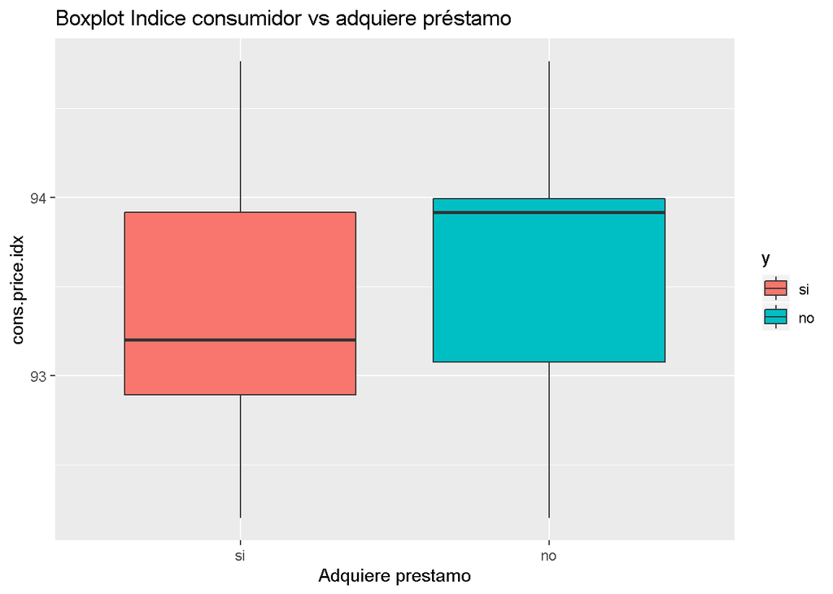

```r
ggplot(data_banco, aes(y, cons.price.idx)) +
  geom_boxplot(aes(fill = y)) +
  labs(title = "Boxplot Indice consumidor vs adquiere préstamo",
      x= "Adquiere prestamo")
```

La distribución del índice cuando no se tiene el préstamo tiene una mediana mayor que cuando sí, sin embargo los cuartiles no muestran mayor diferencia.

Podríamos ahora analizar todos los índices a la vez a través de un gráfico compuesto, para esto haremos varios gráficos que guardaremos en objetos de R y con ellos construiremos un gráfico compuesto usando el comando plot_grid

```r
plot_consprice <- ggplot(data_banco, aes(y, cons.price.idx)) +
  geom_boxplot(aes(fill = y)) +
  labs(title = "Boxplot Indice consumidor \n vs adquiere dep.plazo",
       x= "Adquiere prestamo")
plot_consconf <- ggplot(data_banco, aes(y, cons.conf.idx)) +
  geom_boxplot(aes(fill = y)) +
  labs(title = "Boxplot Confianza consumidor \n vs adquiere dep.plazo",
       x= "Adquiere prestamo")
plot_euribor3m <- ggplot(data_banco, aes(y, euribor3m)) +
  geom_boxplot(aes(fill = y)) +
  labs(title = "Boxplot tasa euribor \n vs adquiere dep.plazo",
       x= "Adquiere prestamo")
plot_employed <- ggplot(data_banco, aes(y, nr.employed)) +
  geom_boxplot(aes(fill = y)) +
  labs(title = "Boxplot Numero empleados \n vs adquiere dep.plazo",
       x= "Adquiere prestamo")
```

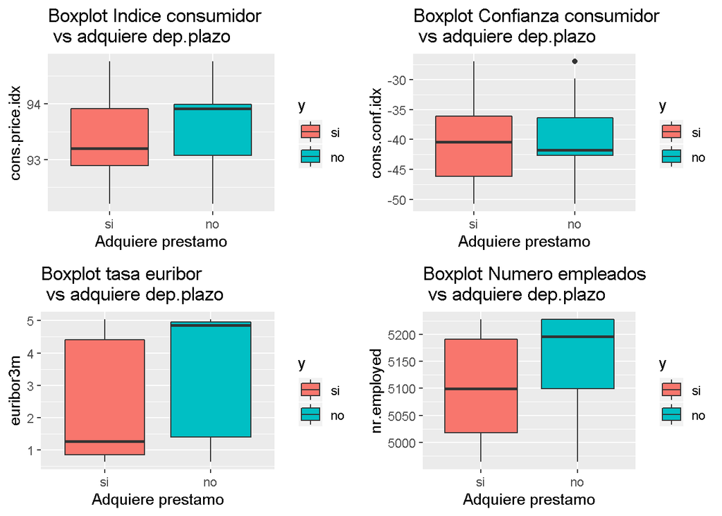

```r
# Grafico compuesto
plot_grid(plot_consprice, plot_consconf, plot_euribor3m, plot_employed, nrow = 2, ncol= 2)
```

Para todos los índices se muestra un comportamiento parecido al anterior, es decir, la distribución del índice cuando no se tiene el préstamo tiene una mediana mayor que cuando sí (excepto en índice de confianza), sin embargo los cuartiles no muestran mayor diferencia, en la variable que sí se ven diferencias es en el **número de empleados** donde la mediana para los que no adquieron el depósito a plazo es casi igual al cuartil 3 de los que sí lo cogen.

**¿La edad está relacionada con la aceptación o no del depósito a plazo?**

Así como en el caso anterior, empezaremos con una tabla de estadísticas descriptivas.

```r
data_banco %>%
  group_by(y) %>%
  summarise(
    Q25= quantile(age, probs = 0.25),
    Media= mean(age),
    Media_Acotada= median(age, trim = 0.05),
    Mediana= mean(age),
    Q75= quantile(age, probs = 0.75)
            )
```

```
## # A tibble: 2 x 6
##   y       Q25 Media Media_Acotada Mediana   Q75
##   <fct> <dbl> <dbl>         <dbl>   <dbl> <dbl>
## 1 si       31  40.9            37    40.9    50
## 2 no       32  39.9            38    39.9    47
```

Y ahora haremos un histograma, escogeremos 10 como el ancho del intervalo.

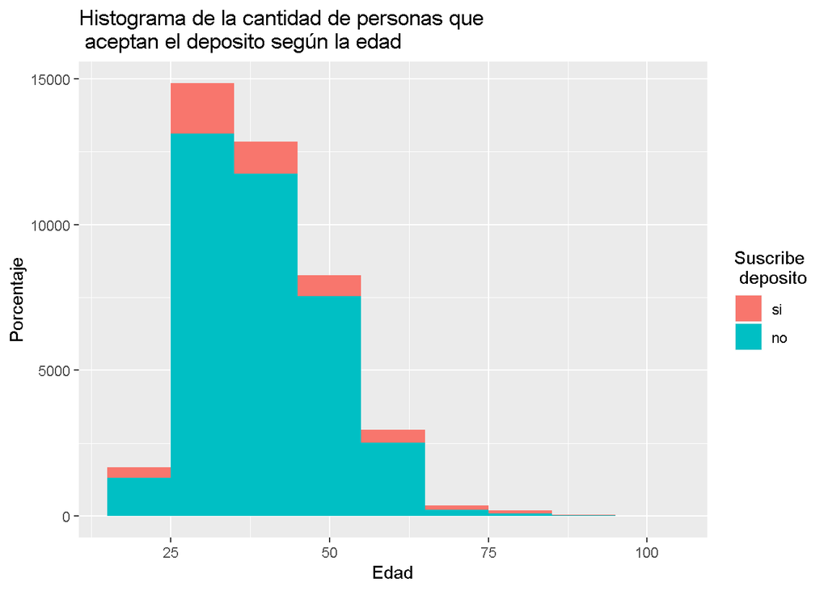

```r
ggplot(data_banco, aes(age)) +
  geom_histogram(aes(fill = y), binwidth = 10) +
  labs( x= 'Edad', y= 'Porcentaje', title= 'Histograma de la cantidad de personas que \n aceptan el deposito según la edad', fill= 'Suscribe \n deposito')
```

Pero el gráfico propuesto no permite ver bien si la edad tiene relación con la aceptación, veamos el gráfico en forma de proporción:

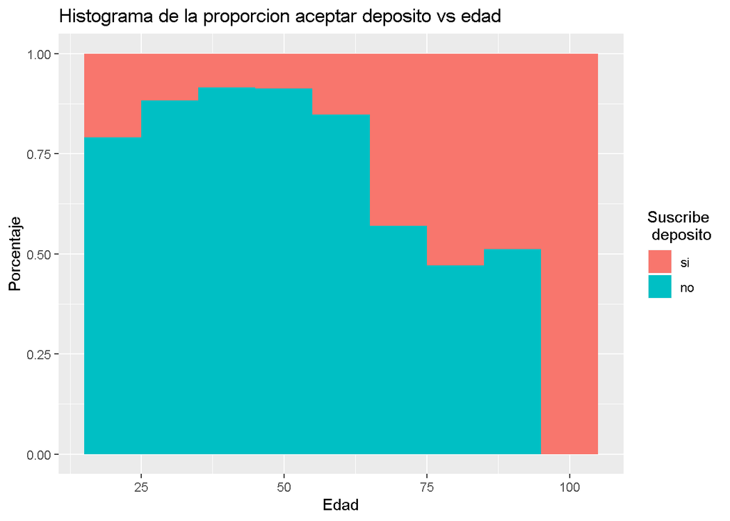

```r
ggplot(data_banco, aes(age)) +
  geom_histogram(aes(fill = y), binwidth = 10, position = 'fill') +
  labs( x= 'Edad', y= 'Porcentaje', title= 'Histograma de la proporcion aceptar deposito vs edad', fill= 'Suscribe \n deposito')
```

**¿Afecta el trabajo a la aceptación de un depósito?**

Empezaremos con una tabla de estadísticas descriptivas, en este caso estamos hablando de dos variables cualitativas, por lo que empezaremos con una tabla de contingencia.

```r
data_banco %$%
  table(job, y) %>%
  prop.table() %>%
  round(digits = 4) * 100
```

```
##                y
## job                si    no
##   admin.         3.28 22.02
##   blue-collar    1.55 20.92
##   entrepreneur   0.30  3.23
##   housemaid      0.26  2.32
##   management     0.80  6.30
##   retired        1.05  3.12
##   self-employed  0.36  3.09
##   services       0.78  8.85
##   student        0.67  1.46
##   technician     1.77 14.60
##   unemployed     0.35  2.11
##   unknown        0.09  0.71
```

Pero veamos si los porcentajes de los que toman el depósito a plazo o no, varían según el trabajo

```r
data_banco %$%
  table(job, y) %>%
  prop.table(margin = 1) %>%
  round(digits = 4) * 100
```

```
##                y
## job                si    no
##   admin.        12.97 87.03
##   blue-collar    6.89 93.11
##   entrepreneur   8.52 91.48
##   housemaid     10.00 90.00
##   management    11.22 88.78
##   retired       25.23 74.77
##   self-employed 10.49 89.51
##   services       8.14 91.86
##   student       31.43 68.57
##   technician    10.83 89.17
##   unemployed    14.20 85.80
##   unknown       11.21 88.79
```

Y ahora un gráfico de barras:

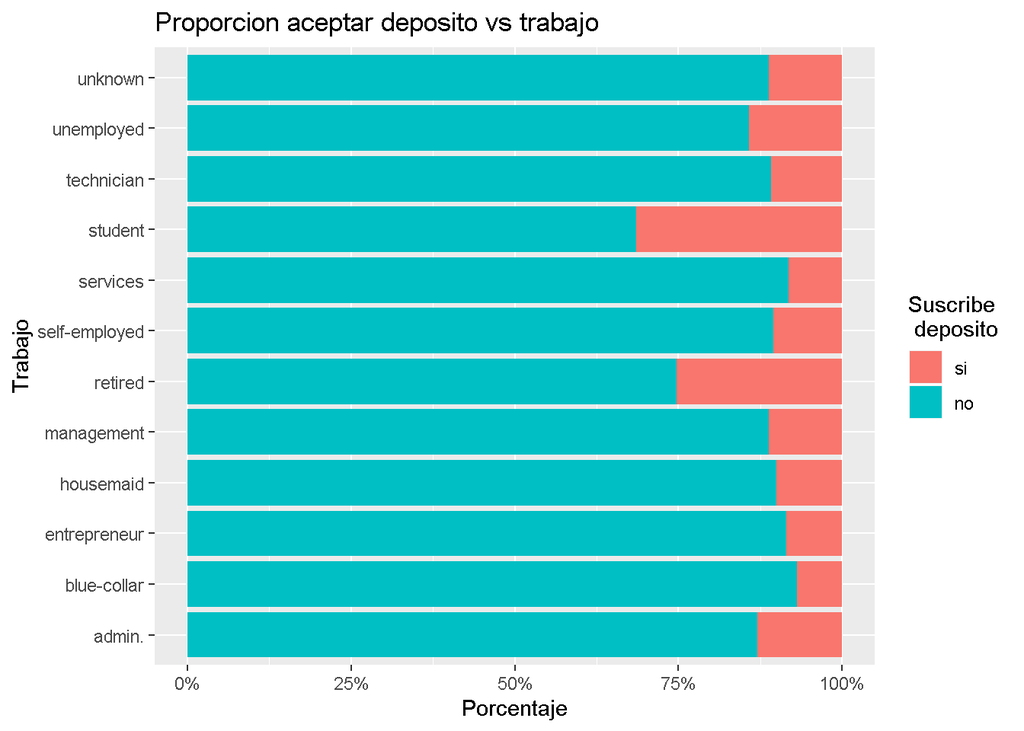

```r
ggplot(data_banco, aes(job)) +
  geom_bar(aes(fill = y), position = 'fill') +
  coord_flip() +
  labs( x= 'Trabajo', y= 'Porcentaje', title= 'Proporcion aceptar deposito vs trabajo', fill= 'Suscribe \n deposito') +
  scale_y_continuous(labels = percent)
```

Interesante ver que los estudiantes y los retirados son los que tienen más propensión a aceptar el depósito a plazo.

**Exploremos los días desde el último contacto**

Haremos un histograma de la variable días desde el último contacto:

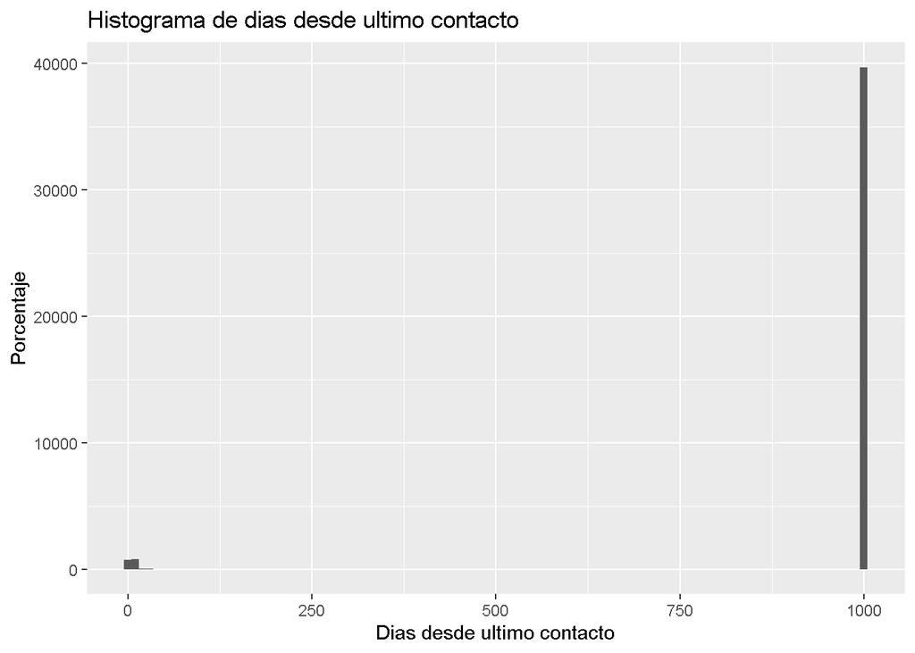

```r
ggplot(data_banco, aes(pdays)) +
  geom_histogram( binwidth = 10) +
  labs( x= 'Dias desde ultimo contacto', y= 'Porcentaje', title= 'Histograma de dias desde ultimo contacto')
```

Como el “999” significaba “no contactado”, se repite el histograma sin este valor

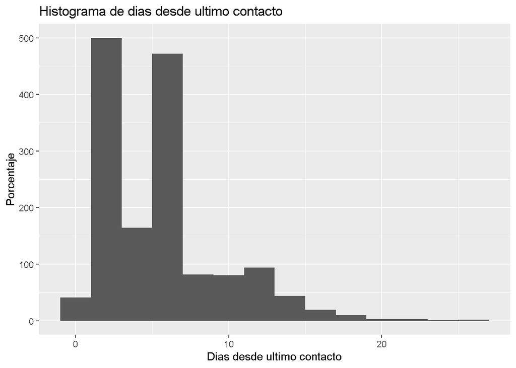

```r
ggplot(data_banco %>% filter(pdays!=999), aes(pdays)) +
  geom_histogram( binwidth = 2) +
  labs( x= 'Dias desde ultimo contacto', y= 'Porcentaje', title= 'Histograma de dias desde ultimo contacto')
```

**pDays** como variable en un modelamiento no nos será útil, vamos a crear una nueva variable que indique si fue contactado o no.

```r
data_banco %<>%
  mutate(pdays_binaria = ifelse(pdays==999, "No", "Si"))

data_banco %$%
  table(pdays_binaria)
```

```
## pdays_binaria
##    No    Si
## 39673  1515
```

**A modo de ejemplo, exploremos la cantidad de llamadas y la tasa eurobor3m vs poseer casa y aceptar depósito**

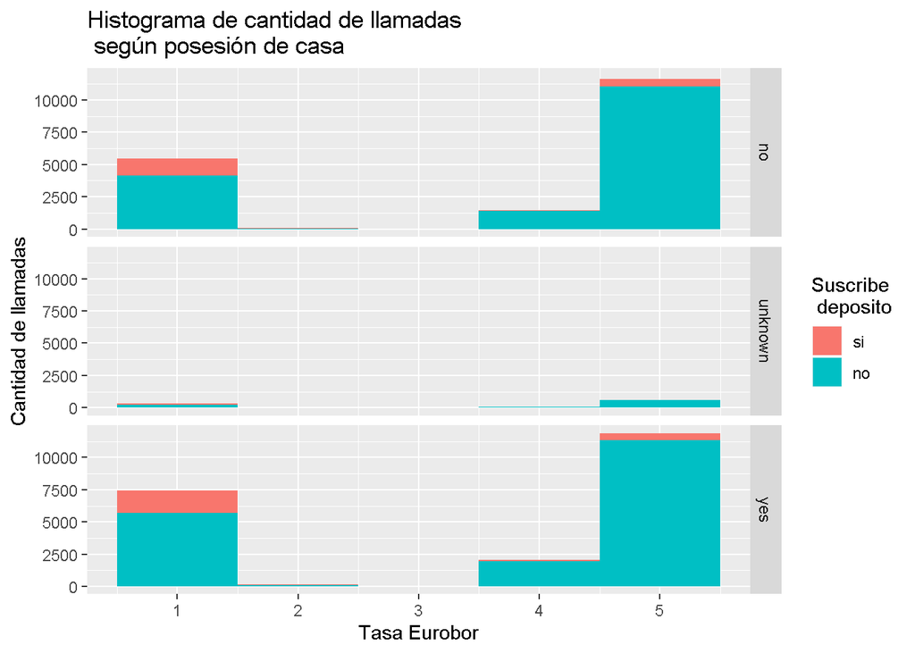

```r
ggplot(data_banco, aes(euribor3m)) +
  geom_histogram(aes(fill = y), binwidth = 1) + facet_grid(housing~. ) +
  labs( x= 'Tasa Eurobor', y= 'Cantidad de llamadas', title= 'Histograma de cantidad de llamadas \n según posesión de casa', fill= 'Suscribe \n deposito')
```

Ahora en porcentaje

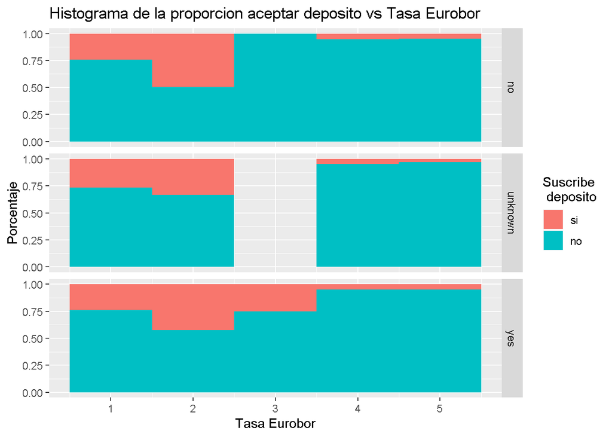

```r
ggplot(data_banco, aes(euribor3m)) +
  geom_histogram(aes(fill = y), binwidth = 1, position = 'fill') + facet_grid(housing~. ) +
  labs( x= 'Tasa Eurobor', y= 'Porcentaje', title= 'Histograma de la proporcion aceptar deposito vs Tasa Eurobor', fill= 'Suscribe \n deposito')
```

## Tú turno

**Ejercicio 1: Explorar el estado civil versus el aceptar o no un depósito**

**Ejercicio 2: Asumamos que nos interesa analizar la duración de la llamada, explore la variable sola y en función de la edad**